# How Accurate Are AT Mobile Bus Wait Predictions?

## Comparing Predictions With Reality

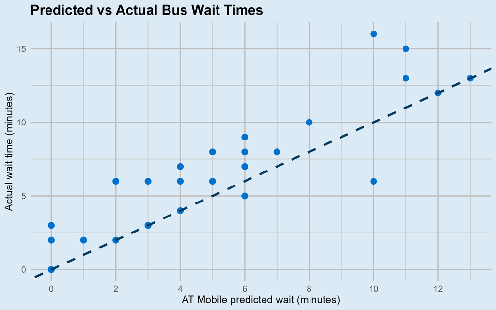

Scatter plot comparing AT Mobile predicted wait times with actual wait times. Most points follow the upward diagonal trend line, showing that longer predicted waits generally correspond to longer actual waits, although several buses arrived later than predicted.

#### Additional information

The dashed reference line represents where the predicted and actual wait times would be equal.

#### Nature of the data

The data was collected from personal bus trips and compares the wait time predicted by AT Mobile with the actual observed wait time at the bus stop.

#### What is being analysed

This plot analyses whether larger predicted wait times generally correspond to larger actual wait times, and whether buses tend to arrive earlier or later than predicted.

### When Is AT Mobile Least Accurate?

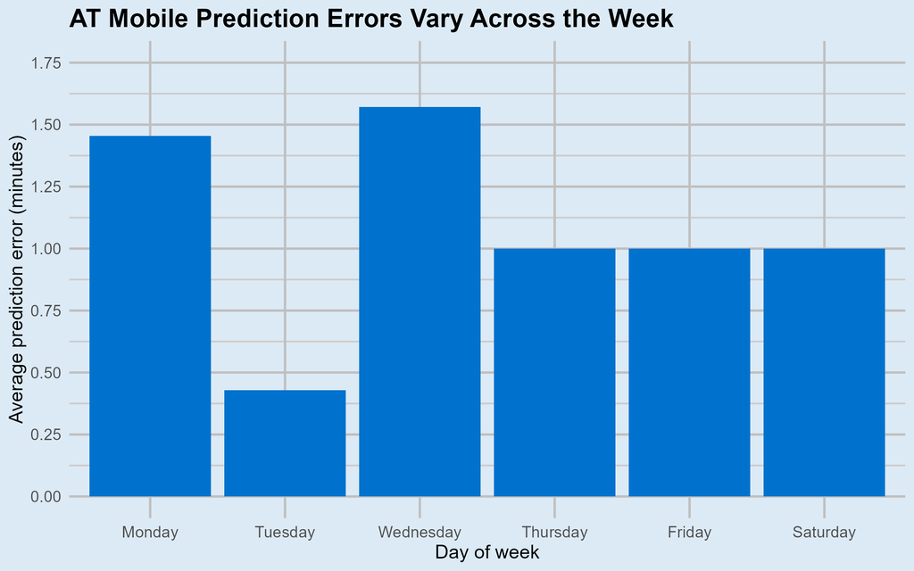

#### Additional information

Prediction error was calculated as the actual wait time minus the predicted wait time. Positive values indicate buses arriving later than predicted, while values close to zero indicate more accurate predictions.

#### Nature of the data

The data groups bus trips by day of the week and calculates the average prediction error for each day.

#### What is being analysed

This plot analyses whether AT Mobile prediction accuracy changes depending on the day of the week.

## Do Wait Times Depend on Time of Day?

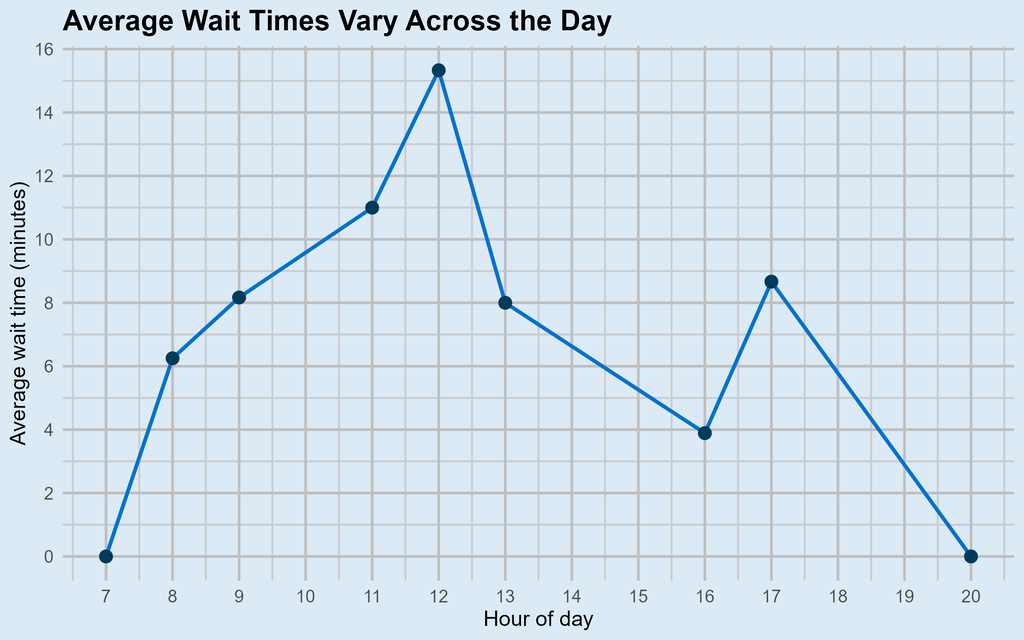

Line plot showing average bus wait times by hour of day. Wait times increase during the morning and midday hours, peak around 12 PM, then generally decrease later in the day.

#### Additional information

The averages shown for some hours are based on fewer observations because most of my recorded bus trips occurred during common commuting periods, particularly in the morning and afternoon.

#### Nature of the data

The data groups bus trips by boarding hour and calculates the average actual wait time for each hour of the day.

#### What is being analysed

This plot analyses how average wait times vary throughout the day and whether certain hours tend to have longer waits.